# 🌿 I modelli di crescita delle popolazioni

### Attività con Python — Biologia + Informatica

In questa attività useremo Python per **costruire grafici** che mostrano come una popolazione può crescere nel tempo.  
Lavoreremo con tre modelli che hai già studiato:

| Modello | Caratteristica |
| --- | --- |
| 🔴 Crescita **esponenziale** | La popolazione cresce sempre più velocemente |
| 🟢 Crescita **logistica** | La crescita rallenta e si stabilizza |
| 🔵 **Espansione e collasso** | La popolazione cresce, raggiunge un picco e poi crolla |

> **Come leggere il notebook:** ogni cella grigia contiene codice Python. Premi **Shift + Invio** (o il tasto ▶) per eseguirla.

## ⚙️ Parte 0 — Prepariamo gli strumenti

Prima di tutto importiamo le librerie che ci servono.

- `random` → per aggiungere un po' di variabilità ai dati (come nella realtà!)
- `matplotlib` → per disegnare i grafici

**Esegui questa cella per prima, poi passa alle parti successive.**

```python
import random
import matplotlib.pyplot as plt

# Fissiamo un seme per avere sempre gli stessi dati "casuali"
random.seed(42)

print("✅ Librerie caricate correttamente!")
```

```
✅ Librerie caricate correttamente!
```

## 🔴 Parte 1 — Crescita Esponenziale

**Formula:** `N(t) = N0 × r^t`

- `N0` = numero iniziale di individui
- `r` = tasso di crescita (es. 2 = raddoppio)
- `t` = tempo

### 📋 Dati rilevati (simulati)

La tabella seguente mostra il numero di batteri misurato ogni ora.  
I dati hanno un piccolo errore di misura, come succede in laboratorio.

```python
# --- DATI SIMULATI: crescita esponenziale ---
# Tempo in ore
ore = [0, 1, 2, 3, 4, 5, 6, 7, 8, 9, 10]

# Numero iniziale di batteri
N0 = 10
# Tasso di crescita (ogni ora la popolazione aumenta del 80%)
r = 1.8

# Generiamo i dati con un piccolo rumore casuale (+/- 10%)
batteri = []
for t in ore:
    valore_teorico = N0 * (r ** t)
    rumore = random.uniform(0.9, 1.1)  # errore tra -10% e +10%
    batteri.append(round(valore_teorico * rumore))

# Stampiamo i dati come tabella
print("Ora  | Numero batteri")
print("-" * 22)
for i in range(len(ore)):
    print(f"  {ore[i]:2d}  |  {batteri[i]}")
```

```
Ora  | Numero batteri
----------------------
   0  |  10
   1  |  16
   2  |  31
   3  |  55
   4  |  110
   5  |  196
   6  |  367
   7  |  562
   8  |  1085
   9  |  1797
  10  |  3370
```

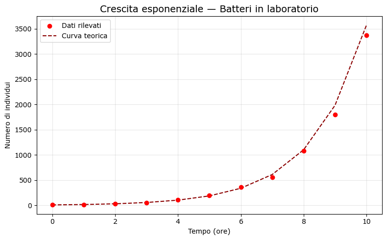

```python
# --- GRAFICO: crescita esponenziale ---
plt.figure(figsize=(8, 5))

# Disegniamo i punti dei dati
plt.scatter(ore, batteri, color='red', zorder=5, label='Dati rilevati')

# Disegniamo la curva teorica
curva = []
for t in ore:
    curva.append(N0 * (r ** t))
plt.plot(ore, curva, color='darkred', linestyle='--', label='Curva teorica')

# Etichette e titolo
plt.title('Crescita esponenziale — Batteri in laboratorio', fontsize=14)
plt.xlabel('Tempo (ore)')
plt.ylabel('Numero di individui')
plt.legend()
plt.grid(True, alpha=0.3)
plt.tight_layout()
plt.show()
```

### ✏️ Domande — Parte 1

Rispondi nelle celle di testo qui sotto (doppio clic per modificare):

**1a.** Guarda il grafico: come cambia la velocità di crescita nel tempo? Rallenta, accelera, o rimane costante?

> *Scrivi qui la tua risposta...*

**1b.** Prova a cambiare il valore di `r` nel codice (es. 1.2 oppure 2.5) e riesegui il grafico. Cosa succede? Perché?

> *Scrivi qui la tua risposta...*

**1c.** Nella realtà, una popolazione di batteri può davvero crescere così per sempre? Cosa la fermerebbe?

> *Scrivi qui la tua risposta...*

## 🟢 Parte 2 — Crescita Logistica

**La capacità portante K** è il numero massimo di individui che l'ambiente può sostenere.

**Formula logistica:**  
`N(t) = K / (1 + ((K - N0) / N0) × e^(-r×t))`

> Non devi capire tutta la formula — Python la calcola per noi! L'importante è capire il **significato** del parametro K.

```python
import math

# --- DATI SIMULATI: crescita logistica ---
# Tempo in mesi
mesi = list(range(0, 25))  # da 0 a 24 mesi

# Parametri della popolazione
N0 = 4        # numero iniziale (2 coppie di conigli)
K = 200       # capacità portante (massimo sostenibile dall'isola)
r = 0.35      # tasso di crescita

# Calcoliamo i valori con rumore
conigli = []
for t in mesi:
    denominatore = 1 + ((K - N0) / N0) * math.exp(-r * t)
    valore_teorico = K / denominatore
    rumore = random.uniform(0.92, 1.08)
    valore = round(valore_teorico * rumore)
    conigli.append(max(1, valore))  # minimo 1 individuo

# Stampiamo alcuni dati
print("Mese  | Conigli")
print("-" * 18)
for i in range(0, len(mesi), 3):  # ogni 3 mesi
    print(f"  {mesi[i]:2d}   |  {conigli[i]}")
```

```
Mese  | Conigli
------------------
   0   |  4
   3   |  11
   6   |  29
   9   |  68
  12   |  109
  15   |  149
  18   |  187
  21   |  195
  24   |  199
```

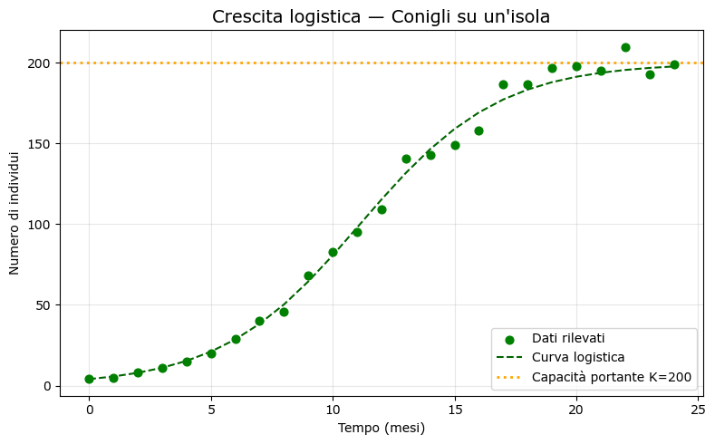

```python
# --- GRAFICO: crescita logistica ---
plt.figure(figsize=(8, 5))

# Dati rilevati
plt.scatter(mesi, conigli, color='green', zorder=5, label='Dati rilevati', s=40)

# Curva teorica
curva_log = []
for t in mesi:
    denom = 1 + ((K - N0) / N0) * math.exp(-r * t)
    curva_log.append(K / denom)
plt.plot(mesi, curva_log, color='darkgreen', linestyle='--', label='Curva logistica')

# Linea della capacità portante
plt.axhline(y=K, color='orange', linestyle=':', linewidth=2, label=f'Capacità portante K={K}')

plt.title('Crescita logistica — Conigli su un\'isola', fontsize=14)
plt.xlabel('Tempo (mesi)')
plt.ylabel('Numero di individui')
plt.legend()
plt.grid(True, alpha=0.3)
plt.tight_layout()
plt.show()
```

### ✏️ Domande — Parte 2

**2a.** Descrivi l'andamento della curva: in quale fase cresce più velocemente? Quando rallenta?

> *Scrivi qui la tua risposta...*

> *Scrivi qui la tua risposta...*

**2c.** Prova a cambiare `K = 100` oppure `K = 400` e riesegui. Cosa cambia nel grafico?

> *Scrivi qui la tua risposta...*

**2d.** Fai un esempio reale: quale fattore potrebbe determinare la K per una popolazione di lupi in un bosco?

> *Scrivi qui la tua risposta...*

## 🔵 Parte 3 — Espansione e Collasso

**Scenario:** Una specie di insetti (es. afidi) colonizza un campo in primavera.  
In estate la popolazione esplode, ma in autunno le piante muoiono e la popolazione crolla.

Questo modello è chiamato anche **"boom and burst"** in inglese.

La curva ha la forma di una **campana asimmetrica**: salita rapida, picco, discesa brusca.

```python
# --- DATI SIMULATI: espansione e collasso ---
# Tempo in settimane (una stagione: ~30 settimane)
settimane = list(range(0, 31))

# Parametri
N0 = 50           # popolazione iniziale
picco = 15        # settimana in cui si raggiunge il picco
ampiezza = 2000   # dimensione massima della popolazione
crescita = 0.4    # velocità di crescita
crollo = 0.6      # velocità di crollo (più ripida della crescita)

# Generiamo i dati: crescita esponenziale poi calo rapido
insetti = []
for t in settimane:
    if t <= picco:
        # Fase di crescita
        valore = N0 * math.exp(crescita * t)
    else:
        # Fase di collasso (dal picco)
        valore_picco = N0 * math.exp(crescita * picco)
        valore = valore_picco * math.exp(-crollo * (t - picco))

    rumore = random.uniform(0.85, 1.15)  # rumore più alto, come nella realtà
    insetti.append(max(0, round(valore * rumore)))

# Stampa
print("Settimana | Insetti")
print("-" * 22)
for i in range(0, len(settimane), 5):
    print(f"    {settimane[i]:2d}    |  {insetti[i]}")
```

```
Settimana | Insetti
----------------------
     0    |  55
     5    |  319
    10    |  2403
    15    |  18414
    20    |  905
    25    |  52
    30    |  2
```

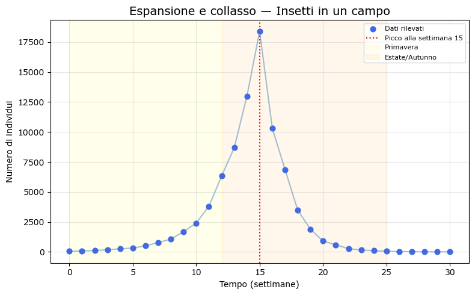

```python
# --- GRAFICO: espansione e collasso ---
plt.figure(figsize=(8, 5))

plt.scatter(settimane, insetti, color='royalblue', zorder=5, label='Dati rilevati', s=40)
plt.plot(settimane, insetti, color='steelblue', alpha=0.5)

# Segniamo il picco
picco_valore = max(insetti)
settimana_picco = insetti.index(picco_valore)
plt.axvline(x=settimana_picco, color='red', linestyle=':', linewidth=1.5,
            label=f'Picco alla settimana {settimana_picco}')

# Annotazione stagioni
plt.axvspan(0, 12, alpha=0.08, color='yellow', label='Primavera')
plt.axvspan(12, 25, alpha=0.08, color='orange', label='Estate/Autunno')

plt.title('Espansione e collasso — Insetti in un campo', fontsize=14)
plt.xlabel('Tempo (settimane)')
plt.ylabel('Numero di individui')
plt.legend(fontsize=8)
plt.grid(True, alpha=0.3)
plt.tight_layout()
plt.show()
```

### ✏️ Domande — Parte 3

**3a.** Perché la discesa è più ripida della salita in questo scenario?

> *Scrivi qui la tua risposta...*

**3b.** Cosa succederebbe alla curva se il crollo fosse più lento (es. `crollo = 0.2`)? Prova!

> *Scrivi qui la tua risposta...*

**3c.** I lemming (roditori della tundra) seguono questo tipo di andamento. Cosa causa il loro crollo?

> *Scrivi qui la tua risposta...*

## 📊 Parte 4 — Confronto tra i tre modelli

Ora mettiamo tutti e tre i grafici insieme per confrontarli visivamente.

Useremo una **scala standardizzata**: normalizziamo ogni popolazione tra 0 e 1,  
così possiamo confrontare la **forma** delle curve indipendentemente dai numeri assoluti.

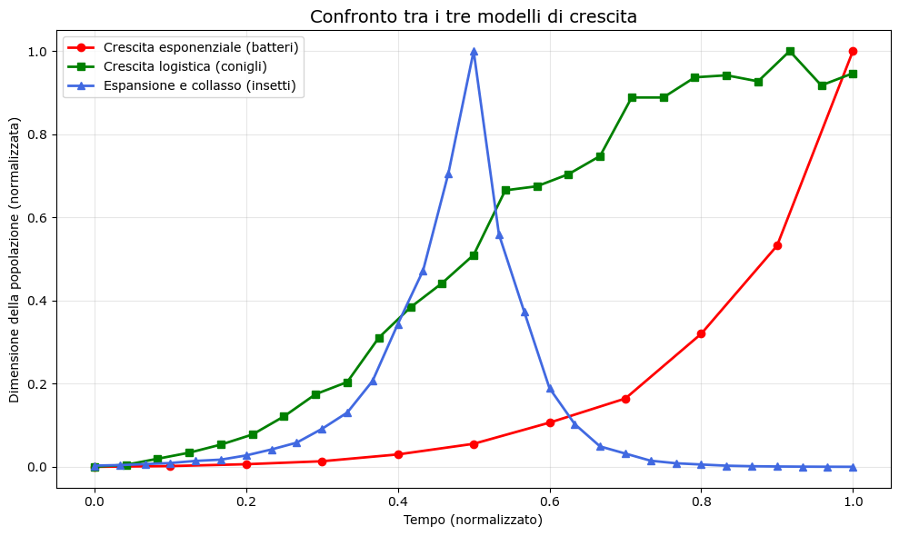

```python
# --- CONFRONTO: i tre modelli normalizzati ---

# Funzione per normalizzare una lista tra 0 e 1
def normalizza(lista):
    minimo = min(lista)
    massimo = max(lista)
    risultato = []
    for v in lista:
        risultato.append((v - minimo) / (massimo - minimo))
    return risultato

# Normalizziamo le tre popolazioni
batteri_norm  = normalizza(batteri)
conigli_norm  = normalizza(conigli)
insetti_norm  = normalizza(insetti)

# Creiamo un asse temporale comune (da 0 a 1)
t_batteri = [i / (len(ore) - 1) for i in range(len(ore))]
t_conigli = [i / (len(mesi) - 1) for i in range(len(mesi))]
t_insetti = [i / (len(settimane) - 1) for i in range(len(settimane))]

# Grafico
plt.figure(figsize=(10, 6))

plt.plot(t_batteri, batteri_norm, 'o-', color='red',
         label='Crescita esponenziale (batteri)', linewidth=2)
plt.plot(t_conigli, conigli_norm, 's-', color='green',
         label='Crescita logistica (conigli)', linewidth=2)
plt.plot(t_insetti, insetti_norm, '^-', color='royalblue',
         label='Espansione e collasso (insetti)', linewidth=2)

plt.title('Confronto tra i tre modelli di crescita', fontsize=14)
plt.xlabel('Tempo (normalizzato)')
plt.ylabel('Dimensione della popolazione (normalizzata)')
plt.legend()
plt.grid(True, alpha=0.3)
plt.tight_layout()
plt.show()
```

### ✏️ Domande finali — Confronto e riflessione

**4a.** Guarda il grafico di confronto: qual è la differenza principale tra la curva rossa e quella verde?

> *Scrivi qui la tua risposta...*

**4b.** Se ricevessi solo una tabella di dati (senza sapere l'animale), come faresti a capire quale modello sta seguendo la popolazione?

> *Scrivi qui la tua risposta...*

**4c.** ⭐ **Sfida:** Quale modello descrive meglio la crescita della popolazione umana negli ultimi 200 anni?  
Fai una ricerca e motiva la tua risposta.

> *Scrivi qui la tua risposta...*

## 🚀 Parte 5 — BONUS: esplora con i tuoi parametri

Qui puoi creare la **tua popolazione immaginaria** modificando i parametri.  
Scegli un animale, scegli i valori e osserva cosa succede!

Hai bisogno solo di modificare la sezione `# === MODIFICA QUI ===`

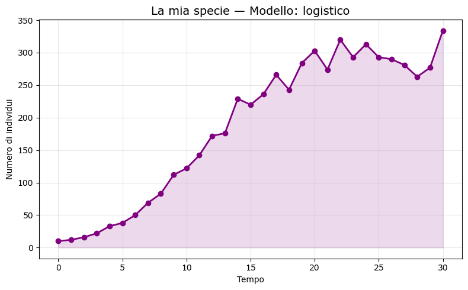

```
Popolazione iniziale: 10
Popolazione finale:   334
Picco massimo:        334 (al periodo 30)
```

```python
# ============================================================
# === MODIFICA QUI: scegli il tuo scenario ===
# ============================================================

nome_animale = "La mia specie"   # ← cambia il nome!
modello = "logistico"             # ← scegli: "esponenziale", "logistico", "collasso"

N0_mio = 10       # popolazione iniziale
r_mio  = 0.3      # tasso di crescita (prova valori tra 0.1 e 1.0)
K_mio  = 300      # capacità portante (solo per modello logistico)
periodi = 30      # numero di periodi di tempo

# ============================================================
# (non modificare il codice sotto)
# ============================================================

random.seed(99)
tempi = list(range(periodi + 1))
mia_pop = []

picco_t = periodi // 2

for t in tempi:
    if modello == "esponenziale":
        v = N0_mio * (math.exp(r_mio * t))
    elif modello == "logistico":
        denom = 1 + ((K_mio - N0_mio) / N0_mio) * math.exp(-r_mio * t)
        v = K_mio / denom
    elif modello == "collasso":
        if t <= picco_t:
            v = N0_mio * math.exp(r_mio * t)
        else:
            v_picco = N0_mio * math.exp(r_mio * picco_t)
            v = v_picco * math.exp(-r_mio * 1.5 * (t - picco_t))
    else:
        print("Modello non riconosciuto! Scegli: esponenziale, logistico, collasso")
        break

    rumore = random.uniform(0.88, 1.12)
    mia_pop.append(max(0, round(v * rumore)))

# Grafico
plt.figure(figsize=(8, 5))
plt.plot(tempi, mia_pop, 'o-', color='purple', linewidth=2)
plt.fill_between(tempi, mia_pop, alpha=0.15, color='purple')
plt.title(f'{nome_animale} — Modello: {modello}', fontsize=14)
plt.xlabel('Tempo')
plt.ylabel('Numero di individui')
plt.grid(True, alpha=0.3)
plt.tight_layout()
plt.show()

print(f"\nPopolazione iniziale: {mia_pop[0]}")
print(f"Popolazione finale:   {mia_pop[-1]}")
print(f"Picco massimo:        {max(mia_pop)} (al periodo {mia_pop.index(max(mia_pop))})")
```

## ✅ Hai completato l'attività!

Ricapitolando quello che hai fatto:

- Hai usato Python per **generare dati** biologici realistici
- Hai costruito **grafici** con matplotlib
- Hai usato **cicli for** e **liste** per calcolare le curve
- Hai confrontato i tre modelli di crescita e ragionato sulle cause biologiche

*Attività realizzata per il collegamento Biologia–Informatica, Classe Seconda*